# Gradient Descent for Linear Regression

Rishikesh Yadav

2024-08-08

# Introduction

In this document, we demonstrate the implementation of a gradient descent algorithm for linear regression. Our goal is to fit a linear model to synthetic data and visualize the results. We will cover the following steps:  
1. Defining the loss function and its gradient.  
2. Implementing the gradient descent algorithm.  
3. Generating synthetic data.  
4. Running the gradient descent and visualizing the results.

```r
# Load necessary libraries
library(ggplot2)  # For creating plots
library(gridExtra)  # For arranging multiple plots in a grid layout
```

# Define the Loss Function and Gradient

We define the Mean Squared Error (MSE) as the loss function and its gradient for linear regression.

```r
# Define the loss function (Mean Squared Error for linear regression)
loss_function_linear <- function(w, data) {
  y_pred <- predict_linear(data$x, w)  # Predict y using the linear model
  sum((data$y - y_pred)^2) / nrow(data)  # Compute and return the Mean Squared Error
}

# Define the gradient of the loss function for linear regression
gradient_linear <- function(w, data) {
  y_pred <- predict_linear(data$x, w)  # Predict y using the linear model
  gradients <- c(
    -2 * sum(data$y - y_pred) / nrow(data),  # Gradient for the intercept
    -2 * sum((data$y - y_pred) * data$x) / nrow(data)  # Gradient for the slope
  )
  return(gradients)  # Return the gradients
}
```

# Linear Prediction Function

We define a function to predict `y` using the linear model.

```r
# Linear prediction function
predict_linear <- function(x, w) {
  y_pred <- w[1] + w[2] * x  # Compute the predicted y using the linear model
  return(y_pred)  # Return the predicted y
}
```

# Gradient Descent Algorithm

We implement the gradient descent algorithm to optimize the coefficients of the linear model.

```r
# Gradient descent algorithm for linear regression
gradient_descent_linear <- function(data, learning_rate, iterations) {
  w <- c(0, 0)  # Initialize coefficients to zero
  history <- data.frame(iteration = integer(iterations), intercept = numeric(iterations), slope = numeric(iterations), loss = numeric(iterations))  # Create a data frame to store the history of coefficients and loss

  for (i in 1:iterations) {
    grads <- gradient_linear(w, data)  # Compute gradients
    w <- w - learning_rate * grads  # Update coefficients using gradient descent
    loss <- loss_function_linear(w, data)  # Compute loss
    history[i, ] <- c(i, w[1], w[2], loss)  # Store iteration, coefficients, and loss
  }

  return(history)  # Return the history of the gradient descent process
}
```

# Generate Synthetic Data

We generate synthetic data for the linear regression model.

```r
# Generate synthetic data
set.seed(42)  # Set seed for reproducibility
n <- 1000  # Number of data points
x <- rnorm(n)  # Generate random normal data for x
y <- 2 + 3 * x + rnorm(n)  # Generate y with a linear relationship and added noise
data <- data.frame(x = x, y = y)  # Create a data frame with x and y
```

# Scatter Plot of the Data

We visualize the generated synthetic data with a scatter plot.

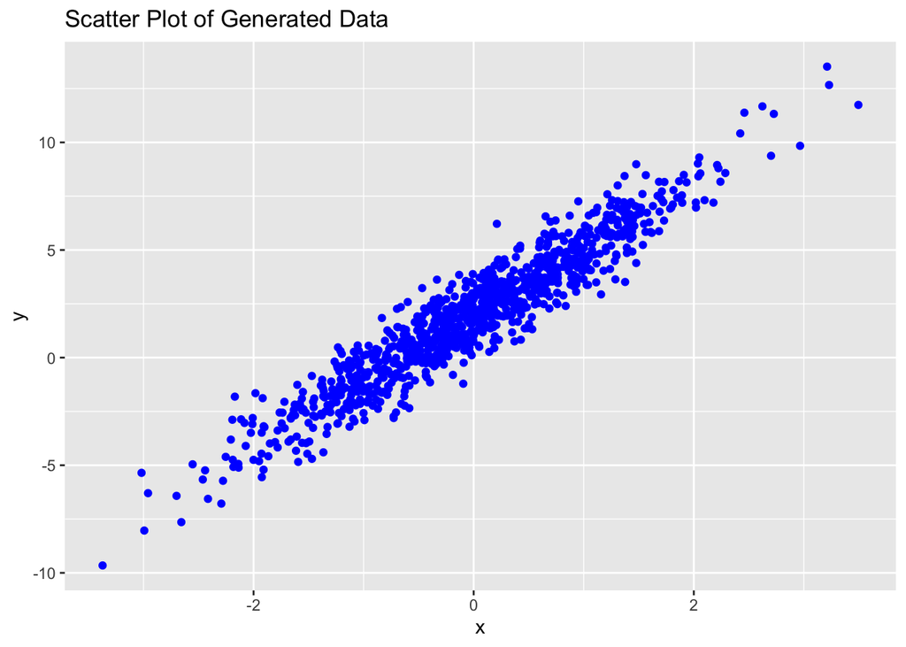

```r
# Scatter plot of the generated data
ggplot(data, aes(x = x, y = y)) +
  geom_point(color = 'blue') +
  labs(title = "Scatter Plot of Generated Data", x = "x", y = "y")
```

# Perform Gradient Descent

We run the gradient descent algorithm to find the optimal coefficients.

```r
# Perform gradient descent for linear regression
learning_rate <- 0.01  # Learning rate for gradient descent
iterations <- 1000  # Number of iterations for gradient descent
history <- gradient_descent_linear(data, learning_rate, iterations)  # Perform gradient descent
```

# Visualize the Results

We create plots to visualize the data, the final regression line, and the convergence of the loss function, intercept, and slope.

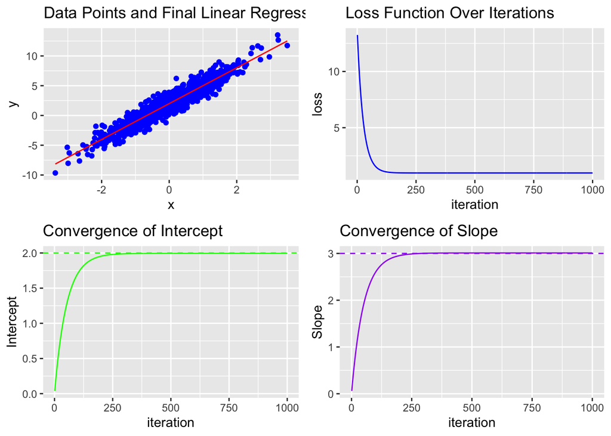

```r
# Plot the data points and the final regression line
data$y_pred <- predict_linear(data$x, as.numeric(history[iterations, 2:3]))  # Predict y using the final coefficients from gradient descent
p1 <- ggplot(data, aes(x = x, y = y)) +
  geom_point(color = 'blue') +  # Plot data points
  geom_line(aes(y = y_pred), color = 'red') +  # Plot the regression line
  labs(title = "Data Points and Final Linear Regression Line")  # Add a title to the plot

# Plot the loss function over iterations
p2 <- ggplot(history, aes(x = iteration, y = loss)) +
  geom_line(color = 'blue') +  # Plot the loss over iterations
  labs(title = "Loss Function Over Iterations")  # Add a title to the plot

# Plot the convergence of the intercept
p3 <- ggplot(history, aes(x = iteration, y = intercept)) +
  geom_line(color = 'green') +  # Plot the convergence of the intercept
  geom_hline(yintercept = 2, linetype = "dashed", color = "green") +  # Add a dashed line at the true value of the intercept
  labs(title = "Convergence of Intercept", y = "Intercept")  # Add a title and y-axis label to the plot

# Plot the convergence of the slope
p4 <- ggplot(history, aes(x = iteration, y = slope)) +
  geom_line(color = 'purple') +  # Plot the convergence of the slope
  geom_hline(yintercept = 3, linetype = "dashed", color = "purple") +  # Add a dashed line at the true value of the slope
  labs(title = "Convergence of Slope", y = "Slope")  # Add a title and y-axis label to the plot

# Save the plots to a PDF file
#pdf("gradient_descent_linear_plots.pdf", width = 12, height = 12)  # Create a PDF file to save the plots
grid.arrange(p1, p2, p3, p4, nrow = 2, ncol = 2)  # Arrange the four plots in a 2x2 grid layout
```

```r
#dev.off()  # Close the PDF device
```

# Conclusion

In this document, we successfully implemented and visualized the gradient descent algorithm for linear regression. We demonstrated how to define the loss function and its gradient, generate synthetic data, and visualize the results of the gradient descent optimization process.